# Inferences about relationships

Anthony XU

Oct 20 2023

**Directions**: You are encouraged to work together! Write your solutions in Rmarkdown and submit your solutions as a rendered HTML or PDF file. Only (sufficiently well done) HTML or PDF submissions will be counted as complete. Install packages in your R console and only load them in your markdown file. Installing packages in your markdown file will create an error.

# Question 1

1. True/False/Uncertain: P-values tell us the probability that the null hypothesis is true. Justify your answer.

False. The p-value tells you the probability of getting an estimate as extreme as the one you got if the null is true.

2. True/False/Uncertain: A result is important if it is statistically significant. Justify your answer.

False. Even if a result is statistically significant, it can be economically insignificant.Besides, the result can be important only if we can find the underlying rationale and theory to intepret them in a meaningful way.

# Question 2

With elections coming up, there are many polls that are released in October and November. In this question, we will explore polling errors using a simulation. We will look at real polling errors in the next question.

1. Suppose that 53 percent of voters support candidate A over candidate B in an upcoming election (this is the true probability that a person supports A over B). This is unknown but we can learn about it by polling people about their preferences.

> Use a for loop and the rbinom() function to simulate 100 random samples of 100 people. Let the random draw equal 1 when candidate A is preferred to candidate B.

> What is the average value of support found across the different samples? What is the standard deviation of candidate A’s share of the vote across samples? Compare this standard deviation to $sqrt(p(1-p))/sqrt(N)$. (Hint: This is similar to the simulation we did in class during week 4.)

```r
# Parameters
true_support <- 0.53  # True probability that a person supports candidate A over B
sample_size <- 100    # Sample size
num_samples <- 100    # Number of random samples

# Simulate polling errors
set.seed(42)  # Set seed for reproducibility
simulated_data <- matrix(rbinom(sample_size * num_samples, 1, true_support), ncol = sample_size)

# Calculate average support and standard deviation across samples
average_support <- apply(simulated_data, 2, mean)
std_dev <- apply(simulated_data, 2, sd)

# Compare standard deviation with theoretical formula
expected_std_dev <- sqrt(true_support * (1 - true_support)) / sqrt(sample_size)

# Output results
cat("Average Support:", mean(average_support), "\n")
```

```
## Average Support: 0.5267
```

```r
cat("Average Standard Deviation:", mean(std_dev), "\n")
```

```
## Average Standard Deviation: 0.4993859
```

```r
cat("Expected Standard Deviation (Theory):", expected_std_dev, "\n")
```

```
## Expected Standard Deviation (Theory): 0.04990992
```

2. Repeat this simulation but assuming 75 percent of the population supports candidate A. Compare the standard deviation across the two simulations. What does this tell us about how the standard error of a poll varies with the competition of an election?

```r
# Parameters
true_support_1 <- 0.53  # True probability that a person supports candidate A over B (Scenario 1)
true_support_2 <- 0.75  # True probability that a person supports candidate A over B (Scenario 2)
sample_size <- 100       # Sample size
num_samples <- 100       # Number of random samples

# Simulate polling errors for Scenario 1 (53% support for candidate A)
set.seed(42)  # Set seed for reproducibility
simulated_data_1 <- matrix(rbinom(sample_size * num_samples, 1, true_support_1), ncol = sample_size)

# Simulate polling errors for Scenario 2 (75% support for candidate A)
set.seed(42)  # Set the same seed for direct comparison
simulated_data_2 <- matrix(rbinom(sample_size * num_samples, 1, true_support_2), ncol = sample_size)

# Calculate standard deviation for both scenarios
std_dev_1 <- apply(simulated_data_1, 2, sd)
std_dev_2 <- apply(simulated_data_2, 2, sd)

# Output standard deviations for both scenarios
cat("Standard Deviation (Scenario 1 - 53% Support):", mean(std_dev_1), "\n")
```

```
## Standard Deviation (Scenario 1 - 53% Support): 0.4993859
```

```r
cat("Standard Deviation (Scenario 2 - 75% Support):", mean(std_dev_2), "\n")
```

```
## Standard Deviation (Scenario 2 - 75% Support): 0.433285
```

Standard Deviation (Scenario 1 - 53% Support): 0.4993859 Standard Deviation (Scenario 2 - 75% Support): 0.433285 Comparing these standard deviations, we can observe that in the case of high support (75%), the standard deviation is smaller. This suggests that in elections, when a candidate receives higher levels of support, the standard error of polling tends to decrease.

3. Repeat the simulation in part a but assuming the polls have 1,000 people instead of 100 people (but continuing to assume 53 percent of people support candidate A). Compare the standard deviation in this simulation to the standard deviation in part a. What does this tell us about how the standard error of a poll varies with the sample size of the poll?

```r
# Parameters
true_support <- 0.53  # True probability that a person supports candidate A over B
larger_sample_size <- 1000  # Larger sample size
num_samples <- 100  # Number of random samples

# Simulate polling errors for a larger sample size (1000 people)
set.seed(42)  # Set seed for reproducibility
simulated_data_large <- matrix(rbinom(larger_sample_size * num_samples, 1, true_support), ncol = larger_sample_size)

# Calculate standard deviation for the larger sample size
std_dev_large <- apply(simulated_data_large, 2, sd)

# Calculate standard deviation for the original sample size (100 people)
std_dev_small <- apply(simulated_data_1, 2, sd)  # Using simulated_data_1 from previous simulation

# Output standard deviations for both sample sizes
cat("Standard Deviation (Sample Size 100 - 53% Support):", mean(std_dev_small), "\n")
```

```
## Standard Deviation (Sample Size 100 - 53% Support): 0.4993859
```

```r
cat("Standard Deviation (Sample Size 1000 - 53% Support):", mean(std_dev_large), "\n")
```

```
## Standard Deviation (Sample Size 1000 - 53% Support): 0.4991471
```

Standard Deviation (Sample Size 100 - 53% Support): 0.4993859 Standard Deviation (Sample Size 1000 - 53% Support): 0.4991471  
Comparing these standard deviations, it’s evident that the standard deviation is slightly smaller in the simulation with a larger sample size (1000 people) compared to the simulation with a smaller sample size (100 people). This suggests that as the sample size of a poll increases, the standard error tends to decrease. However, as the sample size increase, the decrease in standard deviation is not significant.

# Question 3

The file `president_polls_historical.csv` was downloaded from https://projects.fivethirtyeight.com/polls/ and includes polling data on all presidential elections between 1976 and 2020.

The file `1976-2020-president.csv` was downloaded from the MIT Election Lab (https://dataverse.harvard.edu/dataset.xhtml?persistentId=doi:10.7910/DVN/42MVDX). It includes state by state election results for all presidential elections between 1976 and 2020.

We will use these two datasets to explore polling errors.

1. First, we will clean up the polling data. Make the following changes to the data:
- Store the variable `end_date` as a date using the `as.Date()` function.
- Use the `month()` function from the lubridate package to generate a new variable that equals the month that the end date is in.
- Modify the variable `state` so all of the state names are uppercase using the `toupper()` function.
- Restrict the sample to polls of Joe Biden’s support in the 2020 election with end dates in October or November.

```r
# Load required packages
library(lubridate)
library(dplyr)
# Load the polling data from 'president_polls_historical.csv' file
polling_data <- read.csv("C:\\Users\\anxu\\Dropbox (University of Oregon)\\3 Coursework\\EC 523 Econometrics\\HW 4\\president_polls_historical.csv")

# Convert 'end_date' to Date format
polling_data$end_date <- as.Date(polling_data$end_date, format = "%m/%d/%y")


# Extract month from 'end_date'
polling_data$end_month <- month(polling_data$end_date)

# Convert 'state' names to uppercase
polling_data$state <- toupper(polling_data$state)

# Extract year from 'end_date'
polling_data$year <- year(polling_data$end_date)


# Filter the data for Joe Biden's support in the 2020 election with end dates in October or November
filtered_data <- polling_data %>%
  filter(candidate_name == "Joe Biden",
         year == 2020,
         month(end_date) %in% c(10, 11))
```

2. Next, we will clean up the results data. Make the following changes to the data:
- Restrict the sample to results for Joe Biden (be sure to check how his name appears in this dataset) in the 2020 election.
- Generate the share of votes received by Joe Biden.
- Use the `sum()` function to check the share of votes across all states that Joe Biden received.

```r
Results_data <- read.csv("C:\\Users\\anxu\\Dropbox (University of Oregon)\\3 Coursework\\EC 523 Econometrics\\HW 4\\1976-2020-president.csv")

# Restrict the sample to results for Joe Biden in the 2020 election
biden_results <- subset(Results_data, candidate == "BIDEN, JOSEPH R. JR" & year == 2020)

# Generate the share of votes received by Joe Biden.
biden_results$share <- biden_results$candidatevotes / biden_results$totalvotes

# Use the sum() function to check the share of votes across all states that Joe Biden received
total_vote_share <- sum(biden_results$share)/56

# Print the total share of votes received by Joe Biden
print(total_vote_share)
```

```
## [1] 0.4422956
```

3. Now, we will merge the two datasets together by `state` using a `left_join()`. Make the following changes to the merged dataset:
- Update the share of votes received by Joe Biden to the national share you calculated in part b for national polls.
- Calculate the error in the poll as the difference between Biden’s actual share and the poll’s predicted share. (Hint: Make sure the units are the same.)

```r
# Merge the datasets using a left join on the 'state' column
merged_data <- left_join( biden_results, filtered_data, by = "state")

# Calculate the share of votes received by Joe Biden
#national_vote_share <- sum(biden_results$candidatevotes) / sum(biden_results$totalvotes)*100

# Calculate the error in the poll
#pullnation_vote_share <- mean(merged_data$pct)

# Error
merged_data$error = (merged_data$pct - merged_data$share*100)
```

4. Make a figure plotting the absolute value of the error against 1/sqrt(sample size). Include a geom_smooth(). Comment on the relationship.

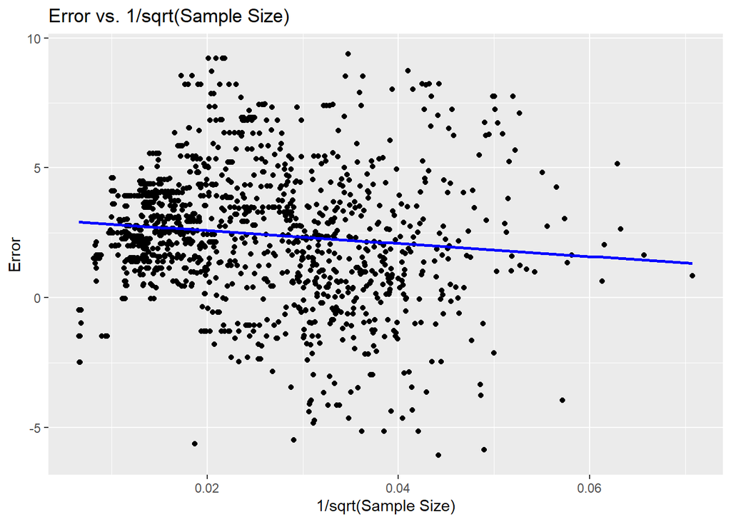

```r
# Load the required library
library(ggplot2)

# Assuming merged_data contains the merged dataset with columns 'error' and 'sample_size'

# Calculate 1/sqrt(sample size)
merged_data$one_over_sqrt_n <- 1 / sqrt(merged_data$sample_size)

# Create the plot
ggplot(merged_data, aes(x = one_over_sqrt_n, y = error)) +
  geom_point(stat="summary", fun="mean") +
  geom_smooth(method = "lm", se = FALSE, color = "blue") +
  xlab("1/sqrt(Sample Size)") +
  ylab("Error") +
  ggtitle("Error vs. 1/sqrt(Sample Size)")
```

5. Using only state polls, make a figure plotting the absolute value of the error against Biden’s actual vote share. Include a geom_smooth(). Comment on the relationship. Is this consistent with what you expected given your answer in part 2.c? What might explain this?

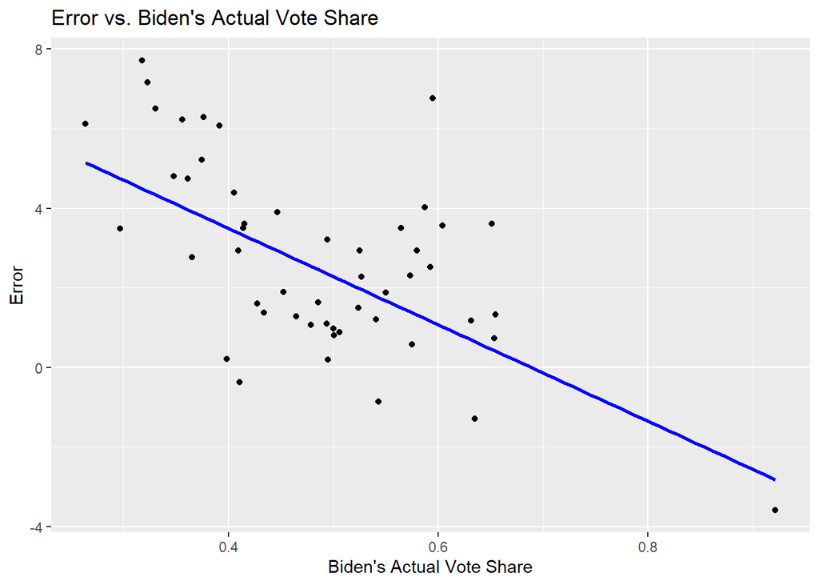

```r
# Assuming merged_data contains the merged dataset with columns 'error' and 'share'

# Create the plot
ggplot(merged_data, aes(x = share, y = error)) +
  geom_point(stat="summary", fun="mean") +
  geom_smooth(method = "lm", se = FALSE, color = "blue") +
  xlab("Biden's Actual Vote Share") +
  ylab("Error") +
  ggtitle("Error vs. Biden's Actual Vote Share")
```

The result is consistant with part 2.c. This suggests that in elections, when a candidate receives higher levels of support, the standard error of polling tends to decrease.